# Project 1 - Song Analysis

Alexandra DeKinder

Many different things define a decade, but few more so than the music. We remember the 60’s for the rise of bands like the Beatles that redefined music, and the 80’s for the loud rock and roll hair bands that morphed into rebellious punk. In this project I will investigate these differences and build a model that uses characteristics of songs and their lyrics to predict the decade the song was created.

### Data Processing and Exploration

I will use the cleaned data that is generated from the Text_Processing.Rmd file. This file includes the variables listed below:

```
[1] "song"         "year"         "artist"       "genre"        "lyrics"       "id"           "stemmedwords"
```

Before I begin to build a model, I first want to investigate the data.

```r
#Number of songs
nrow(dt_lyrics)
```

```
[1] 125704
```

```r
#The different genres represented
levels(as.factor(dt_lyrics$genre))
```

```
 [1] "Country"       "Electronic"    "Folk"          "Hip-Hop"       "Indie"         "Jazz"
 [7] "Metal"         "Not Available" "Other"         "Pop"           "R&B"           "Rock"
```

```r
#The number of different artistis represented
count<-levels(as.factor(dt_lyrics$artist))
length(count)
```

```
[1] 2535
```

```r
#Date range of the data
min(dt_lyrics$year)
```

```
[1] 112
```

```r
max(dt_lyrics$year)
```

```
[1] 2016
```

When looking at the date range of the songs, we see that there is a song with the year 112. In order to determine the reason for this we need to further inspect the data.

One way to check to see if there are any other odd dates in the data, we can look at any observations with a year less than 1000.

```r
#Checking for other outliers
dt_lyrics[dt_lyrics$year < 1000,]
```

| song | year | artist | genre | lyrics | id | stemmedwords |
| --- | --- | --- | --- | --- | --- | --- |
| star | 702 | clipse | Hip-Hop | You're my star\nIt's such a wonder how you shine\nSo no matter how far\nI'm dancing with you in my mind\nHow I find the time to think about\nWhat we had before\nWhen everybody that I know is\nDancing … | 64364 | youre stars shine matter dance mind time dance floor left time slow corner mind boy honest impaired health boy dance youre stars shine matter dance mind baby cool left friend youre harmony note call p… |
| anywhere-remix | 112 | dru-hill | Hip-Hop | Here we are all alone\nYou and me, privacy\nAnd we can do anything\nYour fantasy\nI wanna make your dreams come true\nCan you hear?\nShe's calling me\nBetween your legs\nLoud and clear\nI wanna talk b… | 91140 | privacy fantasy dream true hear shes call legs loud talk love hear scream love bedroom floatin top waterbed kiss run fingers hair hallway stairs love shower body drip wet patio night forget kitchen fl… |

The above outut shows that there are actually two observations with dates outside of a normal range. One solution would be if there was clearly an error, like a date should be 1992 but is written as 992, then one could infer that the 1 was left off and just correct the data point manually. In this case, it does not appear that this is the obvious error so in order to be safe I will remove these two observations.

```r
#Removing incorrect observations
clean_lyrics <- dt_lyrics %>%
  filter(year > 1000)
```

Now, for my response variable I will be using the decade the the song was written. The given data set gives the year the song was written so I will need to create a new column that contains the decade of the song.

```r
clean_lyrics <- clean_lyrics %>%
  mutate(year = as.numeric(year)) %>%
  mutate(Decade = if_else(year < "1970", "1960",
         if_else( year < "1980" & year > "1969", "1970",
                                 if_else(year < "1990" & year > "1979", "1980",
                                         if_else(year < "2000" & year > "1989", "1990",
                                                 if_else(year < "2010" & year > "1999", "2000",
                                                         if_else(year > "2009", "2010", "NA")))))))
```

I will add the number of words in the song (e.g song length) as another possible predictor variable.

```r
clean_lyrics <- clean_lyrics %>%
  mutate(Length = sapply(strsplit(lyrics, " "), length))
```

The last predictor I will add is the overall sentiment of the song. For this sentiment analysis I will be using a numeric sentiment score$^3$.

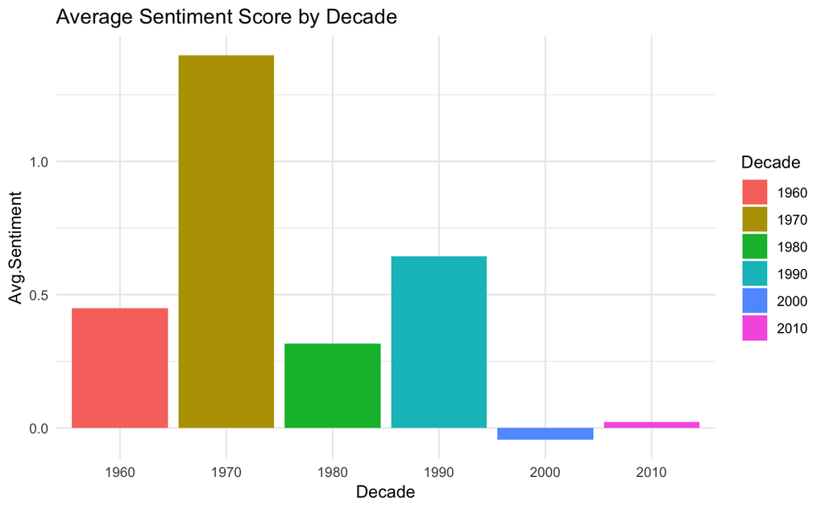

```r
clean_lyrics <- clean_lyrics %>%
  mutate(sentiment=get_sentiment(lyrics)) #Getting sentiment score
clean_lyrics$sentiment <- round(clean_lyrics$sentiment,3) #Rounding score values

#I will visulaize the sentiment score by decade in a bar chart
graph.data <- clean_lyrics %>%
  group_by(Decade) %>%
  summarise(Avg.Sentiment = mean(sentiment))
ggplot(graph.data,aes(x=Decade,y=Avg.Sentiment,fill=Decade)) +
  geom_bar(stat="identity") + theme_minimal() +
  ggtitle("Average Sentiment Score by Decade")
```

In the graph, it is clear the average sentiment score varies greatly between the decades. Before I build the model, I will explore the data further using visuals.

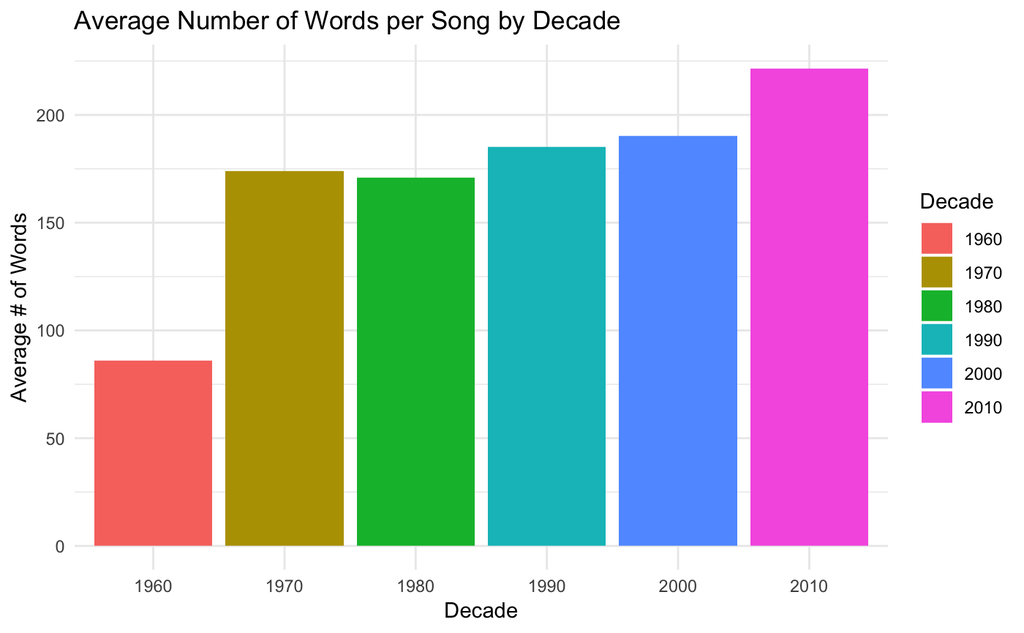

| Decade | Song_Count |
| --- | --- |
| 1960 | 1 |
| 1970 | 1224 |
| 1980 | 1180 |
| 1990 | 4371 |
| 2000 | 93149 |
| 2010 | 25777 |

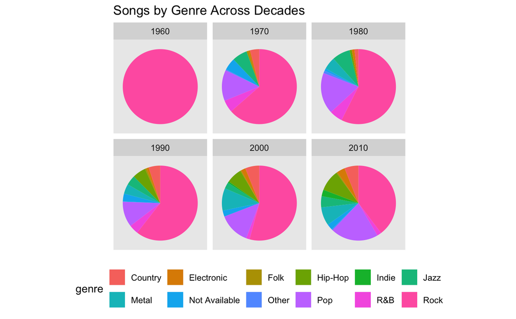

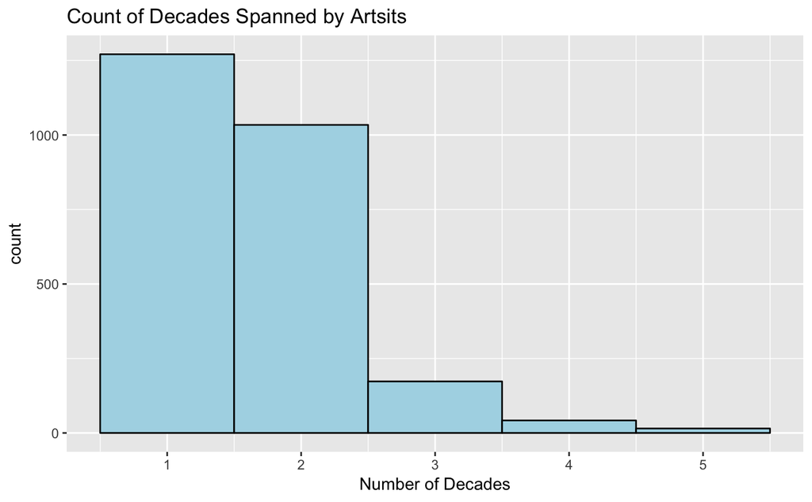

The above graphics highlight some important features of the data. While having variability in the length of song and sentiment scores for each decade is a good thing, the fact that the majority of our songs are from the 2000’s and 2010’s could make building a model challenging. Also, the histogram highlighting the number of decades spanned by artists also has model building implications. Since most of the artists are only present for one or two decades, I will be removing them from the model. Keeping the artist as a predictor would make it too easy to determine the decade and I would like to focus on the characterstics of the songs themselves.

### Model Building

Before I build my classification model, I am going to visualize the correlation between variables in a correlation plot.

#### Correlation Plot

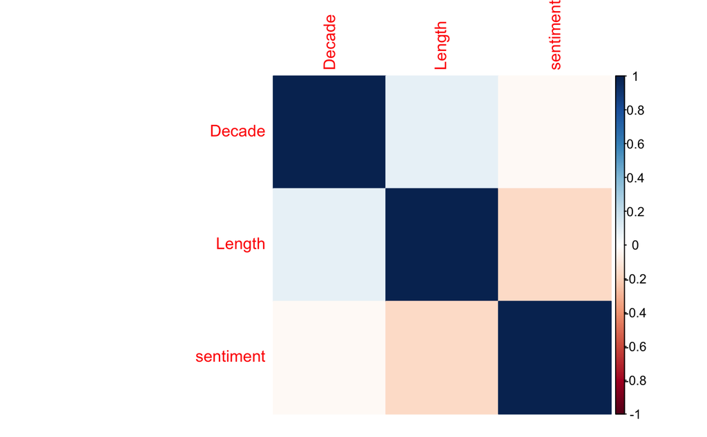

```r
plot.data <- final_lyrics %>%
  dplyr::select(Decade, Length, sentiment)#Selecting the numeric variables
plot.data <- plot.data %>%
  mutate(Decade = as.numeric(Decade)) %>%
  mutate(Length = as.numeric(Length)) %>%
  mutate(sentiment = as.numeric(sentiment))
cor.plot <- cor(plot.data)
corrplot(cor.plot, method="color")
```

In the correlation plot we can see that length of the song correlates somewhat with decade; however, sentiment appears to have little correaltion. While this is not ideal, it does not mean that certain classification algorithms will not work.

In the next section I will use KNN clustering to see if that is able to put songs into the correct decade.

#### KNN Clustering

KNN clustering$^{1,4}$, at a high level, uses euclidean distance between data to classify the data into groups. KNN is a supervised algorithm, while K-Means is an unsupervised algorithm. KNN works best with numeric data so I will need to change the format of my data so that every variable is numeric. I will also normalize my numeric variables so that the euclidean distances calculated in the algorithm are all at the same scale.

```r
#First I need to split the data into training and test sets
set.seed(1234)
train.rows <- sample(1:nrow(final_lyrics),.80*nrow(final_lyrics))
#Before I run KNN, I will normalize the numeric predictors and dummy code the genre variable
normalize <- function(x) {(x-min(x))/(max(x)-min(x))}
norm.final_lyrics <- final_lyrics
norm.final_lyrics$sentiment <- normalize(final_lyrics$sentiment) #Normalizing variables
norm.final_lyrics$Length <- normalize(final_lyrics$Length)
Genre.data <-as.data.frame(dummy.code(norm.final_lyrics$genre)) #Dummy coding genre
norm.final_lyrics<-norm.final_lyrics[,-c(1:6)]
norm.final_lyrics<-cbind(norm.final_lyrics,Genre.data) #Combining all the processed variables back together
#Separating training set
lyrics_train <- norm.final_lyrics[train.rows,]
#Separating test set
lyrics_test <-  norm.final_lyrics[-train.rows,]
#Extract decade column since that is the response variable
lyrics_decade <-(final_lyrics[train.rows,"Decade"])
lyrics_train <- lyrics_train[,-1]
lyrics_test_decade <- (final_lyrics[-train.rows,"Decade"])
lyrics_test <- lyrics_test[,-1]
#Now I can run the knn function
knn.predict <- knn(lyrics_train,lyrics_test,cl=as.factor(lyrics_decade$Decade),k=7)
```

```
   Cell Contents
|-------------------------|
|                       N |
|-------------------------|


Total Observations in Table:  25141


                                | class_comparison$PredictedDecade
class_comparison$ObservedDecade |      1970 |      1980 |      1990 |      2000 |      2010 | Row Total |
--------------------------------|-----------|-----------|-----------|-----------|-----------|-----------|
                           1970 |         0 |         0 |         0 |       219 |        20 |       239 |
--------------------------------|-----------|-----------|-----------|-----------|-----------|-----------|
                           1980 |         0 |         0 |         1 |       199 |        19 |       219 |
--------------------------------|-----------|-----------|-----------|-----------|-----------|-----------|
                           1990 |         0 |         0 |         1 |       812 |        57 |       870 |
--------------------------------|-----------|-----------|-----------|-----------|-----------|-----------|
                           2000 |         2 |         2 |        18 |     17499 |      1252 |     18773 |
--------------------------------|-----------|-----------|-----------|-----------|-----------|-----------|
                           2010 |         0 |         0 |         3 |      4291 |       746 |      5040 |
--------------------------------|-----------|-----------|-----------|-----------|-----------|-----------|
                   Column Total |         2 |         2 |        23 |     23020 |      2094 |     25141 |
--------------------------------|-----------|-----------|-----------|-----------|-----------|-----------|
```

```r
results <- as.matrix(tab$t)
diagonal<-diag(results)
accuracy <- sum(diagonal)/nrow(lyrics_test)
round(accuracy,2)
```

```
[1] 0.73
```

While at first glance it may seem that a 73% accuracy rate is not bad, upon closer inspection, there are some serious issues with the KNN clustering method. While the algorithm did well with the songs in the 2000’s and 2010’s, it did not correctly assign any of the songs from the earlier decades, except for 1 in the 1990’s. A reason for this is because this data is known as imbalanced data. As it was shown before, a majority of the songs in the data set are from the most recent two decades and because of this, the KNN algorithm will try to assign most of the observations in the test set to these decades. Imbalanced data is not an uncommon problem and there are several methods to use in this situation.

The first method is re-sampling the data$^2$. Essentially, this means taking less data from the over-represented classes and more from the under-represented classes. Since the data set is fairly large, I will use under-sampling for songs in the 2000’s and 2010’s. Another method of over-sampling is SMOTE, which stands for synthetic minority over-sampling technique. SMOTE generates fake samples in the minority class. A non-sampling method would be to add weight to the minority classes in the algorithm.

```r
#Data rebalancing, this must be done after the data is split and only on the training set
#I will pull out 50% of the data from the 2000's and 2010's
set.seed(1234)
removed.rows.2000 <- sample(1:nrow(lyrics_train[lyrics_train$Decade == "2000", ]), #Randomly selecting rows
                       .50*nrow(lyrics_train[lyrics_train$Decade == "2000", ]))
removed.rows.2010 <- sample(1:nrow(lyrics_train[lyrics_train$Decade == "2010", ]),
                       .50*nrow(lyrics_train[lyrics_train$Decade == "2010", ]))
balanced_lyrics_train <- lyrics_train[-c(removed.rows.2000,removed.rows.2010),]
#Extract decade column since that is the response variable
lyrics_decade <-(balanced_lyrics_train[,"Decade"])
balanced_lyrics_train <- balanced_lyrics_train[,-1]
lyrics_test_decade <- (lyrics_test[,"Decade"])
lyrics_test <- lyrics_test[,-1]
#Now we run the knn function
knn.predict <- knn(balanced_lyrics_train,lyrics_test,cl=as.factor(lyrics_decade),k=7)
```

```
   Cell Contents
|-------------------------|
|                       N |
|-------------------------|


Total Observations in Table:  25141


                                | class_comparison$PredictedDecade
class_comparison$ObservedDecade |      1970 |      1990 |      2000 |      2010 | Row Total |
--------------------------------|-----------|-----------|-----------|-----------|-----------|
                           1970 |         0 |         1 |       216 |        22 |       239 |
--------------------------------|-----------|-----------|-----------|-----------|-----------|
                           1980 |         0 |         1 |       197 |        21 |       219 |
--------------------------------|-----------|-----------|-----------|-----------|-----------|
                           1990 |         0 |         1 |       794 |        75 |       870 |
--------------------------------|-----------|-----------|-----------|-----------|-----------|
                           2000 |         2 |        18 |     17469 |      1284 |     18773 |
--------------------------------|-----------|-----------|-----------|-----------|-----------|
                           2010 |         0 |         3 |      4291 |       746 |      5040 |
--------------------------------|-----------|-----------|-----------|-----------|-----------|
                   Column Total |         2 |        24 |     22967 |      2148 |     25141 |
--------------------------------|-----------|-----------|-----------|-----------|-----------|
```

```r
results <- as.matrix(tab$t)
diagonal<-diag(results)
accuracy <- sum(diagonal)/nrow(lyrics_test)
round(accuracy,2)
```

```
[1] 0.08
```

### Conclusions

Data analysis questions are often a process, during which one will realize a selected approach is not working and must look to new methods to try and solve the problem. Also, one might conclude that asking a different question all together might lead to a more useful solution. No matter what the model says, our decades will continue to be defined by their music, and hopefully soon we can unlock the secret to what made each era of music so unique.

### References

1. “K-Nearest Neighbor: An Introductory Example.” K-Nearest Neighbor: An Introductory Example. 17 Sept. 2019

   https://quantdev.ssri.psu.edu/sites/qdev/files/kNN_tutorial.html
2. Nabi, Javaid. “Machine Learning - Multiclass Classification with Imbalanced Dataset.”

   Medium. 22 Dec. 2018. Towards Data Science. 17 Sept. 2019

   <https://towardsdatascience.com/machine-learning-multiclass-classification-with-imbalanced-data-set-29f6a177c  
   1a>.
3. Nishida, Kan. “Twitter Sentiment Analysis - Scoring by Sentence.” Medium. 11 July 2016.

   Learn data science. 18 Sept. 2019

   https://blog.exploratory.io/twitter-sentiment-analysis-scoring-by-sentence-b4d455de3560
4. Sirohi, Kshitiz. “K-nearest Neighbors Algorithm with Examples in R (Simply Explained knn)”.

   Medium. 30 Dec. 2018. Towards Data Science. 17 Sept. 2019

   <https://towardsdatascience.com/k-nearest-neighbors-algorithm-with-examples-in-r-simply-explained-knn-1f2c88d  
   a405c>